# [Reality's Last Stand](https://www.realityslaststand.com/)

# The Ideological Intensification of DEI in STEM

DEI must be stopped from destroying the sciences, the humanities, the arts, and Western civilization at large.

[Mason Goad](https://substack.com/profile/84744685-mason-goad)

Jan 24

[figure not shown]

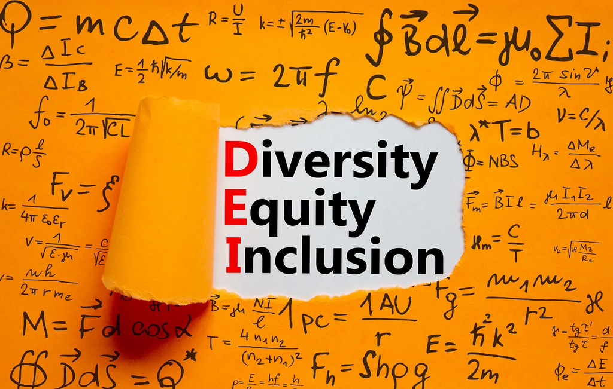

Image Credit: Modified from [Dzmitry Dzemidovich](https://www.istockphoto.com/portfolio/DzmitryDzemidovich?mediatype=photography)

[figure not shown]

Diversity trainings are by no means new; they have been around in one form or another for decades, with the aim of making the social environment more welcoming to people from a wide range of racial, ethnic, and cultural backgrounds. What *is* new, however, is the saturation of such trainings with radical political ideologies and the speed at which they have achieved near ubiquity in both our public and private institutions in the wake of our country’s racial reckoning following George Floyd’s death.

These new ideological trainings are called diversity, equity, and inclusion (or DEI) training, and nowhere are these trainings and bureaucracies more deeply entrenched than at public universities, where they are often intimately involved in all aspects of hiring and promotion. But despite the widespread adoption and [enormous costs](https://www.reportlinker.com/p06219616/Global-Diversity-and-Inclusion-D-I-Industry.html?utm_source=GNW) of DEI trainings, there is scant reason to believe these trainings work, and plenty of reasons to suspect they may [actually](https://hbr.org/2016/07/why-diversity-programs-fail) be doing [more](https://www.heritage.org/education/report/diversity-university-dei-bloat-the-academy) harm than good to on-campus racial relations among students.

University DEI departments largely operate by their own rules that are political rather than educational, and are a primary contributor to the climate of fear and self-censorship on campus [reported](https://www.cspicenter.com/p/academic-freedom-in-crisis-punishment) by many students and academics.

Recently, we have witnessed even more concerning effects of DEI in the sciences. A class of [medical students](https://twitter.com/realchrisrufo/status/1579904917761708034) pledged to honor “indigenous way of healing” and fight against the “gender binary.” The American Psychological Association will now [require](https://www.city-journal.org/american-psychological-association-politicizes-itself) “racial equity” practices to complete training requirements. The National Institutes of Health now [denies access to data](https://www.city-journal.org/nih-blocks-access-to-genetics-database) if the research is deemed politically incorrect. And the Department of Energy will soon require [diversity statements](https://www.wsj.com/articles/science-grants-equity-and-inclusion-energy-department-dei-proposals-hiring-pier-plan-woke-11665153295) from its grant applicants.

The “woke” DEI mind-virus has clearly infected the sciences, but exactly how great is the infection?

In search of an answer the National Association of Scholars commissioned me and my co-author to conduct a new study. Our report, *[Ideological Intensification](https://www.nas.org/reports/ideological-intensification)*, is the largest quantitative study of DEI in STEM to date. We surveyed 100 STEM-focused universities and gathered nearly 60,000 URLs. We then scanned the files for all co-occurrences of a DEI term, a STEM term, and a single, specified date. The rise of DEI in STEM was slow and steady until 2020, when a dramatic spike occurred (likely in response to the Black Lives Matter riots).

Here is the graph of DEI terminology on surveyed university websites over time:

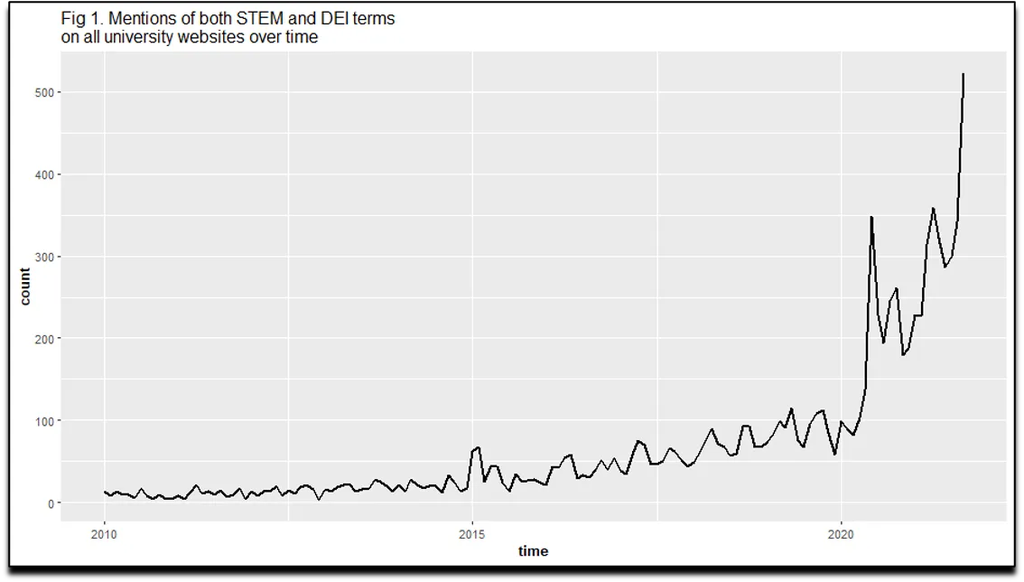

DEI terminology used on surveyed university websites over time.

Mapping the geographic locations of these 100 universities allowed us to visualize the rise of DEI in STEM in other ways as well:

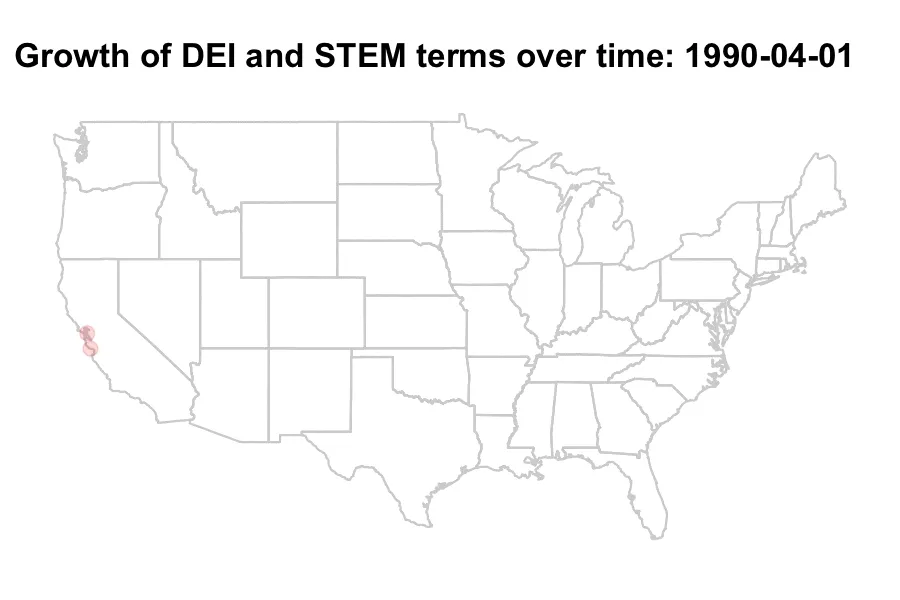

Our dataset of university websites, however, was just the beginning. We then sought to analyze Twitter feeds at those same 100 universities and gathered over 150,000 tweets from 895 unique accounts into a second dataset for additional analysis.

The figures below chart the use of DEI-related language in all university-related accounts, and university primary accounts, respectively:

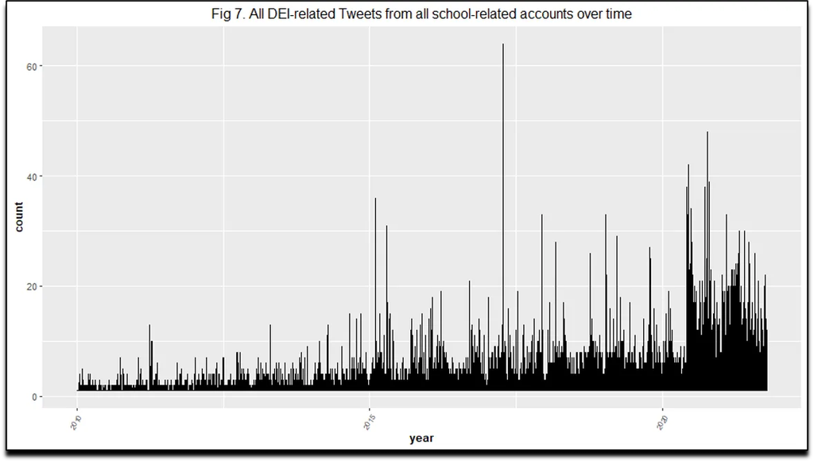

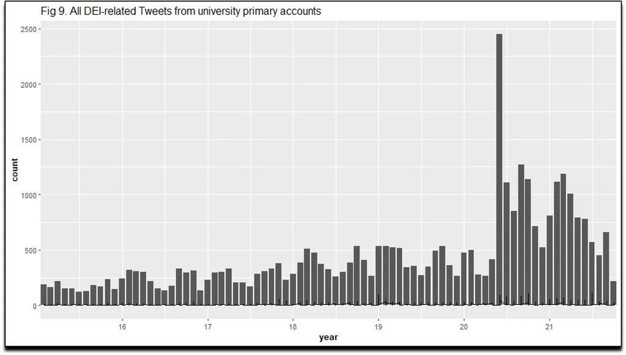

After looking at the websites and tweets of universities across the country, we had practically exhausted our analysis of higher education, but colleges are only part of the scientific ecosystem.

Next, we set off to explore the presence of DEI among scientific associations, and we chose the four largest we could identify based on membership size and financial resources: the American Physical Society, the American Chemical Society, the American Mathematical Society, and the American Society for Biochemistry and Molecular Biology. We collected years of scientific abstracts from (bi-)annual meetings from the first three, and years of newsletters from the fourth.

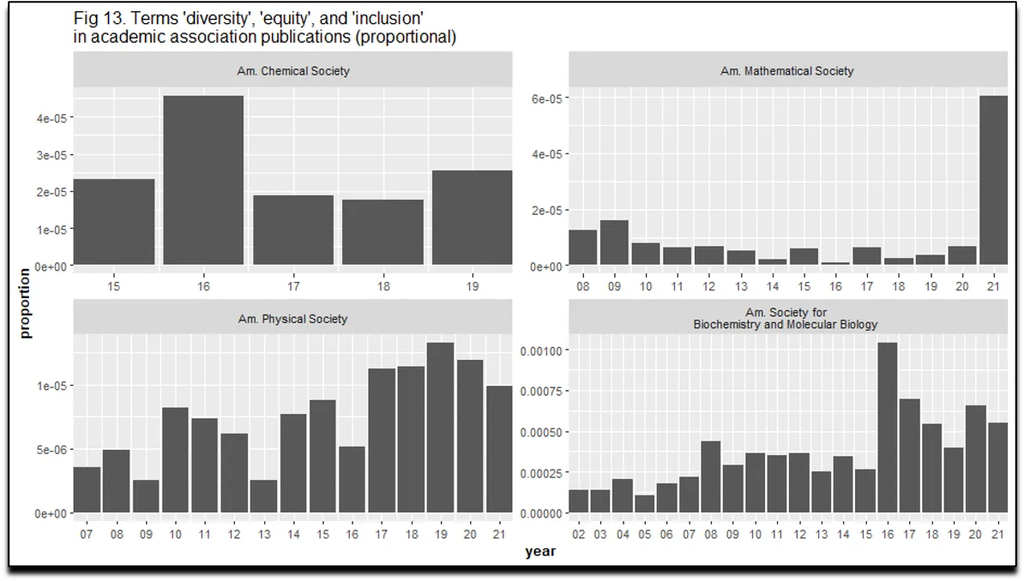

Our findings here were generally mixed. In some cases, the trends went up, in others they went down, and sometimes no trend could be discerned, but it was clear the DEI has found its way into this facet of the scientific community as well. Each of these associations has incorporated DEI in some fashion into their organizational structure, usually in the form of DEI committees.

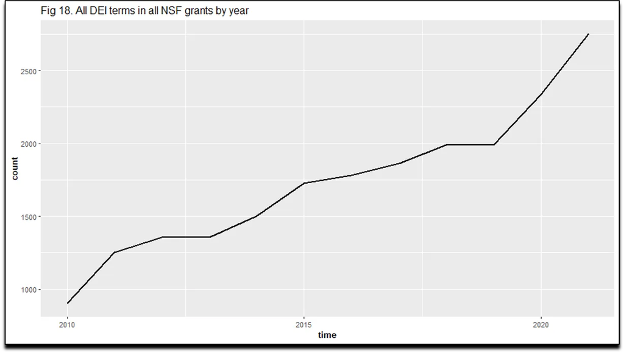

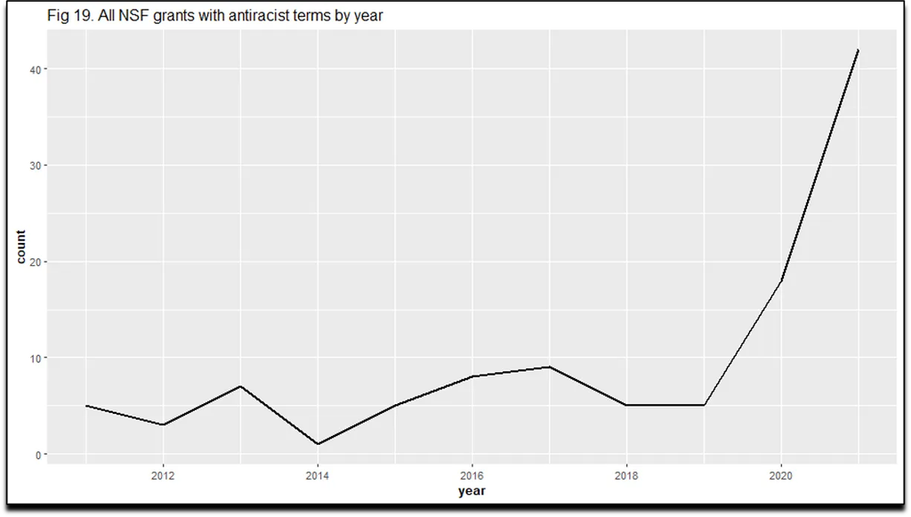

Finally, we set out to explore the scientific literature itself. In the creation of a fifth dataset, we searched the Web of Science, a database containing over 171 million records, and used an open-source software to query Google Scholar. We also pulled data from arXiv, the largest and most well-known preprint server for general scientific publications, and queried PubMed, the leading database of biomedical research.

Once again, DEI-related language has increased at an exponential rate. In the Web of Science, DEI increased up to 42 times faster than science topics generally, with similar trends in Google Scholar and PubMed.

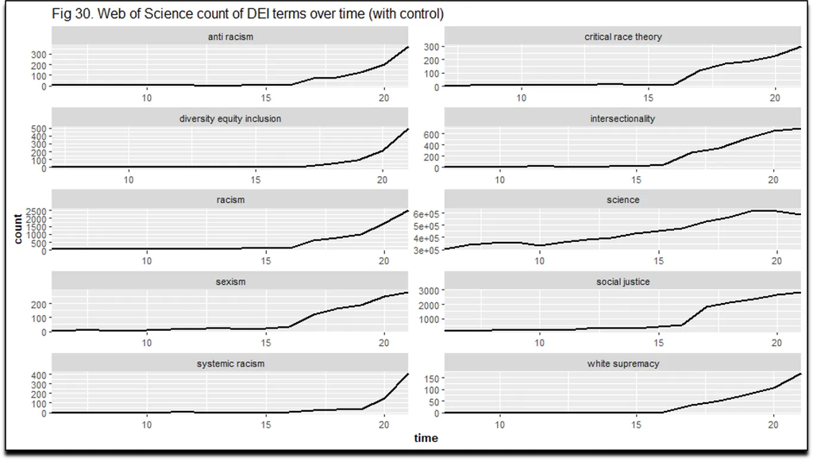

[figure not shown]

Our analysis has shown that DEI ideology has intruded on STEM much more than we initially hypothesized. DEI ideology has come after healthcare, national security, and other fields of immense societal importance. Its intrusion in the sciences continues mostly unabated. This trend is deeply concerning, as the politicization of science leads to the loss of public trust, as well as the loss of time and funding that could otherwise be going to worthwhile projects and innovation.

DEI initiatives may sound wholesome, but the reality is far from it. DEI must be stopped, not only to save the sciences, but the humanities, the arts, and Western civilization at large.

[figure not shown]

### Organizations to Support

- [Society for Evidence-Based Gender Medicine](https://segm.org/) (SEGM)
- [Sex Matters](https://sex-matters.org/take-action/donate/)
- [Parents Defending Education](https://defendinged.org/)
- [Transgender Trend](https://www.transgendertrend.com/)
- [Genspect](https://genspect.org/)
- [Foundation for Individual Rights and Expression (FIRE)](https://www.thefire.org/)
- [Women’s Liberation Front (WoLF)](https://www.womensliberationfront.org/)
- [Women’s Declaration International](https://www.womensdeclaration.com/en/)
- [LGB Alliance](https://lgballiance.org.uk/)
- [Fair Play for Women](https://fairplayforwomen.com/)
- [Counterweight](https://counterweightsupport.com/)
- [The Free Speech Union](https://freespeechunion.org/)
- [Heterodox Academy](https://heterodoxacademy.org/)

A guest post by

| [Mason Goad](https://substack.com/profile/84744685-mason-goad?utm_campaign=guest_post_bio&utm_medium=web) Mason Goad is a research associate at the National Association of Scholars. His areas of acade… |  |
| --- | --- |

Old School Counselor

[Writes Old School Counselor](https://oldschoolcounselor.substack.com/?utm_source=substack&utm_medium=web&utm_content=comment_metadata)

[Jan 24](https://www.realityslaststand.com/p/the-ideological-intensification-of/comment/12169525)·*edited Jan 24*

Hoghopper

[Jan 24](https://www.realityslaststand.com/p/the-ideological-intensification-of/comment/12175087)

[figure not shown]

Feb 19, 2022

[figure not shown]

Feb 1, 2021

[figure not shown]

Aug 19, 2022

© 2023 Colin Wright